# flowAI report

SIgN_GM

## FCS file information

> Input file name: Donor_Spleen_029  
> Number of events: 457168

## Quality control analysis

### Summary

> The anomalies were removed from: Flow Rate, Flow Signal and Flow Margin  
> Anomalies detected in total: **1.36** %  
> Number of high quality events: 450945

### Flow rate check

> **0.02** % anomalies detected in the flow rate check.

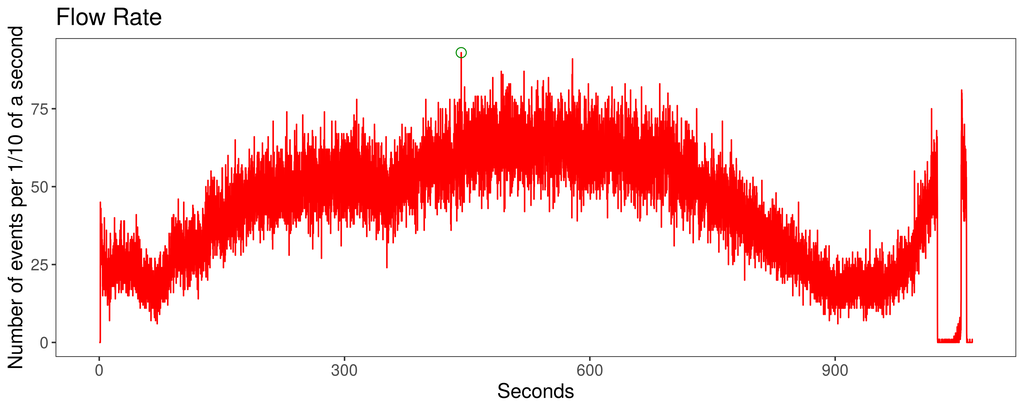

The plot reconstructs the flow rate with a resolution of 1/10 of a second. Anomalies in the flow rate are identified with an algorithm based on the generalied ESD outlier detection method. The anomalies are circled in green.

### Signals acquisition check

> **0** % anomalies detected in the signal aquisition check.

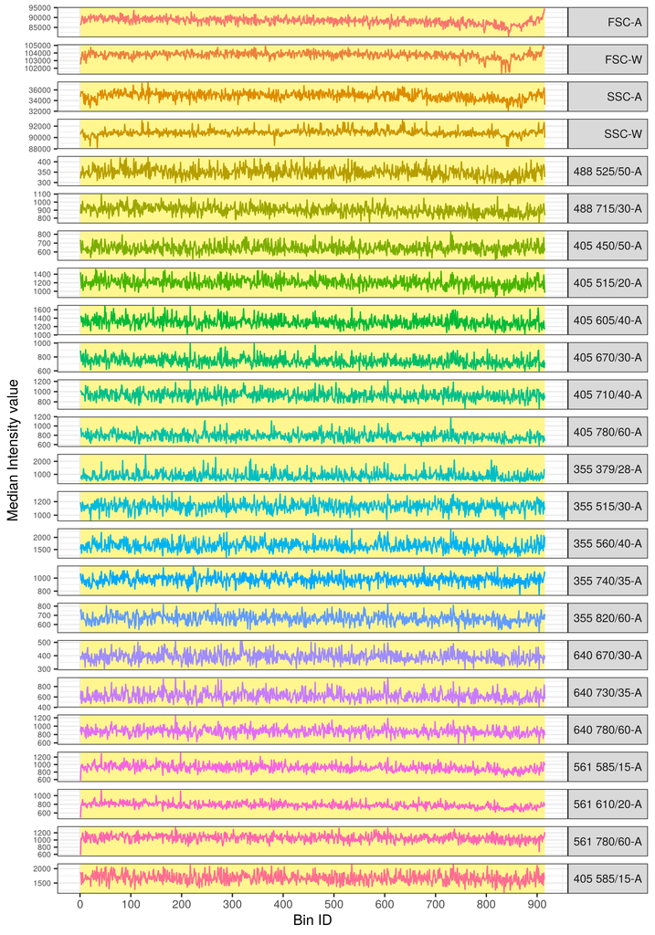

The more stable region selected consistent for all channels is highlighted in yellow. If the removal of outliers has been required before the execution of the changepoint analysis, the detected outliers are cicled in green.

The FCS file was divided in 915 bins, hence each bin contains 500 event(s). The stable region is located between the bins 1 and 915.

##### More info on the changepoints detected

No changepoints were detected.

Channels excluded from the analysis: FSC-A, FSC-W, SSC-A, SSC-W.

No changepoints were detected in the channels: 488 525/50-A, 488 715/30-A, 405 450/50-A, 405 515/20-A, 405 605/40-A, 405 670/30-A, 405 710/40-A, 405 780/60-A, 355 379/28-A, 355 515/30-A, 355 560/40-A, 355 740/35-A, 355 820/60-A, 640 670/30-A, 640 730/35-A, 640 780/60-A, 561 585/15-A, 561 610/20-A, 561 780/60-A, 405 585/15-A.

### Dynamic range check

> **1.34** % anomalies detected in dynamic range check.

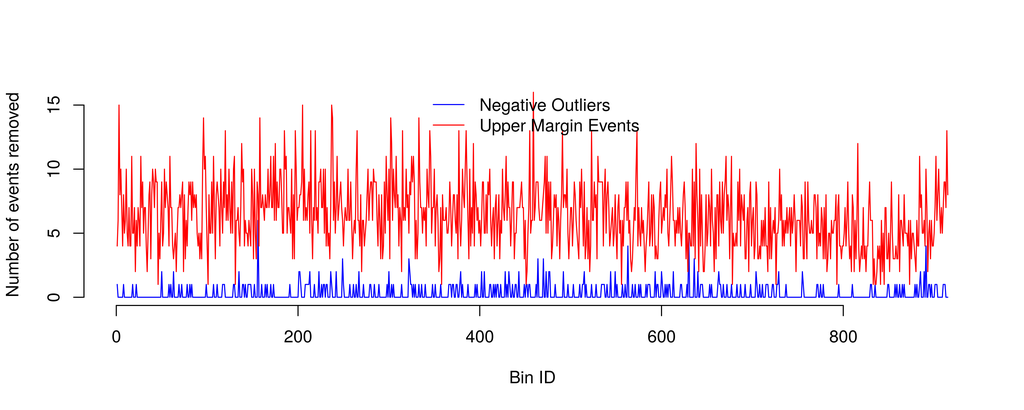

The plot shows where the anomalies occured the most. The x-axis scale is complementary to the one of the signal acquisition plot.

##### More info on the anomalies detected in the dynamic range check

For each channel analyzed, the table shows the number of events that did not pass the dynamic range check:

```
##              lower_range upper_range
## 488 525/50-A          30        1001
## 488 715/30-A          20          13
## 405 450/50-A          24          19
## 405 515/20-A          24        1159
## 405 605/40-A          21          81
## 405 670/30-A          28          24
## 405 710/40-A          28          14
## 405 780/60-A         149           6
## 355 379/28-A          39         140
## 355 515/30-A          21          21
## 355 560/40-A          48          84
## 355 740/35-A          17           5
## 355 820/60-A          40           3
## 640 670/30-A          16           7
## 640 730/35-A          25           6
## 640 780/60-A          28           9
## 561 585/15-A          15        4688
## 561 610/20-A           8        1701
## 561 780/60-A          30          18
## 405 585/15-A          22         129
## total_SUM            633        9128
## total_UNIQUE         293        5842
```

Channels excluded from the analysis: FSC-A, FSC-W, SSC-A, SSC-W.